# Data Task

Octavio E. Lima

11/5/2021

## Loading packages

```r
# Loading libraries and setting work directory
setwd("~/Documents/2021/variant_data_task/code/")

if (!require("pacman")) install.packages("pacman")
pacman::p_load(tidyverse, future, future.apply, parallel, scales, data.table, janitor, knitr, zoo,
               fs, furrr, stringi, ggplot2, ggthemes, reshape2, readxl, stargazer, lubridate, kableExtra)
```

```r
# Loading the data
loan_tape_data <- read_excel("Loan Tape Review.xlsx")
```

## Preparing the Data for Analysis

```r
# Using `janitor` package to turn all column names into lower case (this facilitates the analysis)
loan_tape_data <- loan_tape_data %>% clean_names()

# Removing typo where year is 2028
loan_tape_data <- loan_tape_data[!(loan_tape_data$loan_id == "102096"),]

# Removing $500,000 loan outlier
loan_tape_data <- loan_tape_data[!(loan_tape_data$loan_amount == 500000),]

# creating a column `issue_year`
loan_tape_data <- loan_tape_data %>%
                  mutate(issue_year = year(issue_date))

# Creating `month` column to investigate any possible calendar effects in the data.
loan_tape_data <- loan_tape_data %>%
                  mutate( issue_month = zoo::as.yearmon(issue_date))
loan_tape_data$issue_month <- as.Date(loan_tape_data$issue_month)

# Turning `guarantee` into Indicator (Dummy) Variable
loan_tape_data$guarantee <- ifelse(loan_tape_data$guarantee == "Yes", 1, 0)

# Turning `loan_status` into indicator variable
loan_tape_data$loan_status <- ifelse(loan_tape_data$loan_status == "Repaid", 1, 0)
```

## Summarizing the different types of loans they originate. (i.e. loan characteristics by cohorts)

### This table represents average data points based on Credit Scores ranges.

```r
# Summarizing data amount by credit score
mean_data_by_crd_score <- loan_tape_data %>%
                            mutate(score_range = cut(credit_score, c(400, 500, 600, 700, 800, 900))) %>%
                            group_by(score_range) %>%
                            summarize(average_loan_amount = mean(loan_amount),
                                      average_interest = mean(interest_rate),
                                      average_loan_to_value = mean(loan_to_value),
                                      pctg_collateral_needed = sum(guarantee)/length(guarantee),
                                      pctg_repaid = sum(loan_status) / length(loan_status),
                                      total_loans = length(loan_id))

(mean_data_by_crd_score )%>% kbl(caption = "Table 1") %>% kable_material_dark()
```

Table 1

| score_range | average_loan_amount | average_interest | average_loan_to_value | pctg_collateral_needed | pctg_repaid | total_loans |
| --- | --- | --- | --- | --- | --- | --- |
| (400,500] | 86600.49 | 0.1511092 | 0.7867347 | 0.5612245 | 0.6428571 | 98 |
| (500,600] | 69586.80 | 0.1515342 | 0.8054582 | 0.5687332 | 0.8436658 | 742 |
| (600,700] | 60671.75 | 0.1283026 | 0.8229234 | 0.4598930 | 0.8888889 | 1683 |
| (700,800] | 58326.77 | 0.1089608 | 0.8437189 | 0.3686747 | 0.9341365 | 1245 |
| (800,900] | 58109.10 | 0.1022404 | 0.8510096 | 0.3125000 | 0.9615385 | 208 |

### This table represents average data points based on Credit Ratings.

```r
# summarizing data by credit ratings
mean_data_by_crd_ratings <- loan_tape_data %>%
                            group_by(credit_rating) %>%
                            summarize(average_loan_amount = mean(loan_amount),
                                      average_interest = mean(interest_rate),
                                      average_loan_to_value = mean(loan_to_value),
                                      pctg_collateral_needed = sum(guarantee)/length(guarantee),
                                      pctg_repaid = sum(loan_status) / length(loan_status),
                                      total_loans = length(loan_id))

(mean_data_by_crd_ratings) %>% kbl(caption = "Table 2") %>% kable_material_dark()
```

Table 2

| credit_rating | average_loan_amount | average_interest | average_loan_to_value | pctg_collateral_needed | pctg_repaid | total_loans |
| --- | --- | --- | --- | --- | --- | --- |
| A | 59127.20 | 0.1020070 | 0.8492954 | 0.3073005 | 0.9473684 | 1178 |
| B | 61805.93 | 0.1267559 | 0.8242786 | 0.4547264 | 0.8935323 | 2010 |
| C | 67315.90 | 0.1586516 | 0.7993647 | 0.6327827 | 0.8081321 | 787 |
| D | 74943.00 | 0.3000000 | 0.8000000 | 1.0000000 | 0.0000000 | 1 |

### This table represents average data points based on Year.

```r
# summarizing data by year
mean_data_by_year <- loan_tape_data %>%
                            group_by(issue_year) %>%
                            summarize(average_loan_amount = mean(loan_amount),
                                      average_interest = mean(interest_rate),
                                      average_loan_to_value = mean(loan_to_value),
                                      pctg_collateral_needed = sum(guarantee)/length(guarantee),
                                      pctg_repaid = sum(loan_status) / length(loan_status),
                                      total_loans = length(loan_id))

(mean_data_by_year) %>% kbl(caption = "Table 3") %>% kable_material_dark()
```

Table 3

| issue_year | average_loan_amount | average_interest | average_loan_to_value | pctg_collateral_needed | pctg_repaid | total_loans |
| --- | --- | --- | --- | --- | --- | --- |
| 2015 | 36984.60 | 0.1279318 | 0.8322500 | 0.4571429 | 0.9464286 | 280 |
| 2016 | 54835.73 | 0.1222470 | 0.8275884 | 0.5051975 | 0.9209979 | 481 |
| 2017 | 80400.99 | 0.1263577 | 0.8211538 | 0.4152098 | 0.8758741 | 1144 |
| 2018 | 60372.59 | 0.1275990 | 0.8266731 | 0.4487427 | 0.9323017 | 517 |
| 2019 | 56837.60 | 0.1297043 | 0.8272608 | 0.4613368 | 0.9266055 | 763 |
| 2020 | 55175.98 | 0.1213584 | 0.8319595 | 0.4361568 | 0.8204804 | 791 |

## How has their origination changed over time? (i.e. volumes, loan characteristics, underwriting standards, etc.)

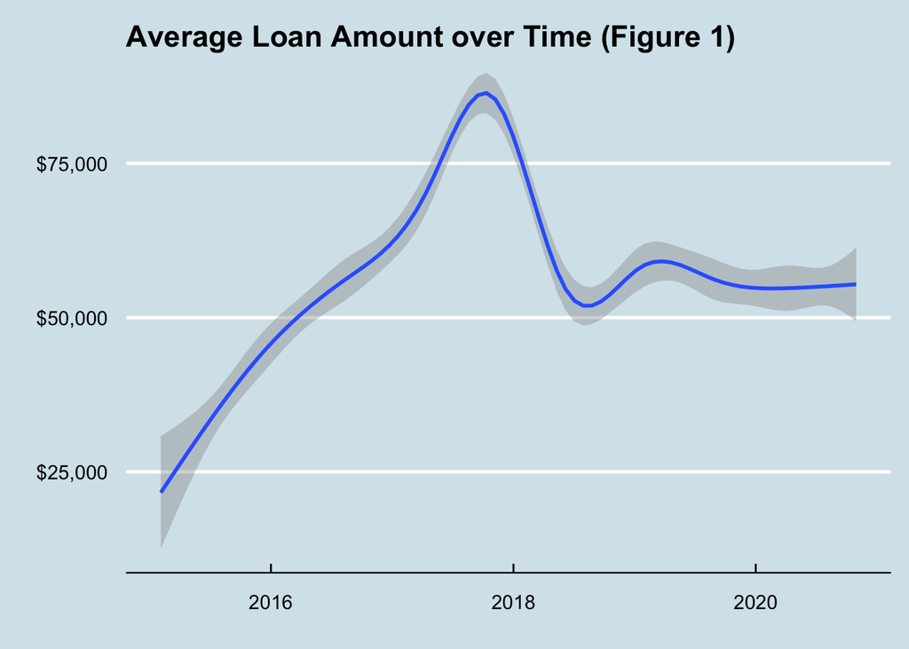

```r
# Disabling scientific notation
options(scipen = 9999)

# Creating plot for the average loan amount over time
loan_tape_data %>%
  group_by(issue_date) %>%
  summarize(avg_loan_amount = mean(loan_amount)) %>%
  ggplot(aes(x = issue_date, y = avg_loan_amount)) +
  geom_smooth() + theme_economist() +
  scale_y_continuous(labels = scales::dollar_format()) +
  ggtitle("Average Loan Amount over Time (Figure 1)") + xlab("") + ylab("")
```

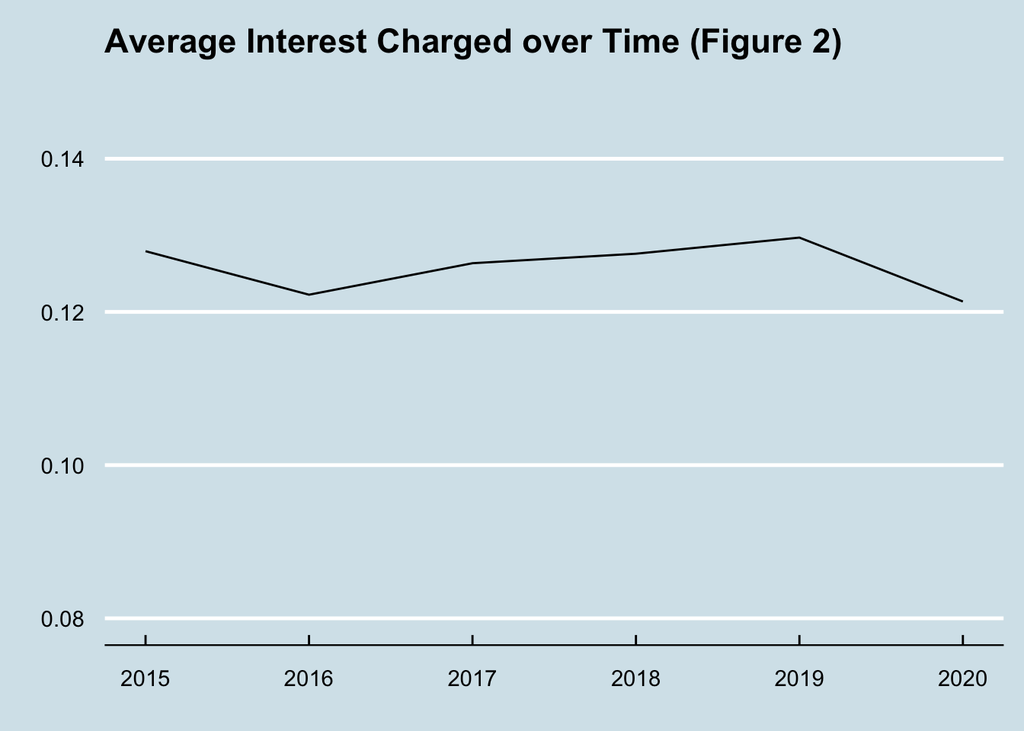

```r
# Creating plot for the average interest charged over time
loan_tape_data %>%
  group_by(issue_year) %>%
  summarize(avg_interest = mean(interest_rate)) %>%
  ggplot(aes(x = issue_year, y = avg_interest)) +
  geom_line() + theme_economist() +
  ggtitle("Average Interest Charged over Time (Figure 2)") +
  ylim(0.08, 0.15) + xlab("") + ylab("")
```

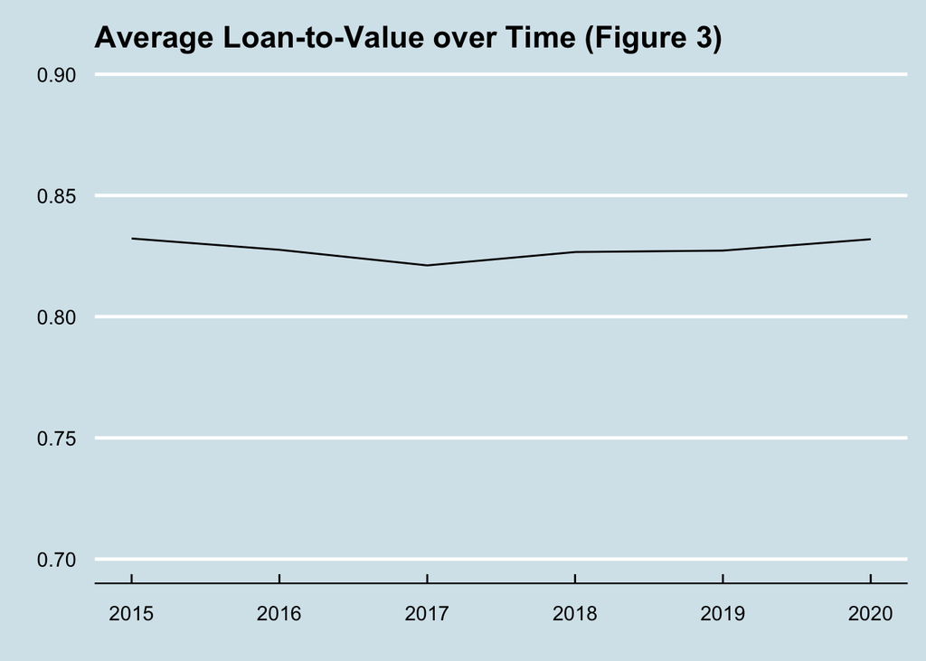

```r
# Creating plot for the average interest charged over time
loan_tape_data %>%
  group_by(issue_year) %>%
  summarize(loan_to_value = mean(loan_to_value)) %>%
  ggplot(aes(x = issue_year, y = loan_to_value)) +
  geom_line() + theme_economist() +
  ggtitle("Average Loan-to-Value over Time (Figure 3)") +
  ylim(0.7, 0.9) + xlab("") + ylab("")
```

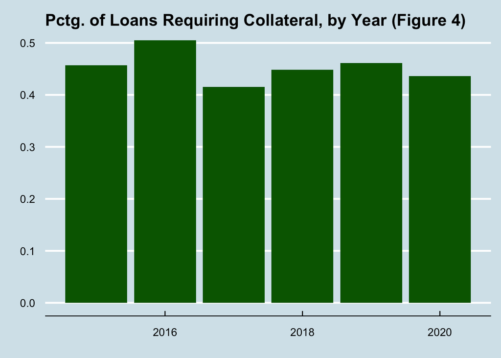

```r
loan_tape_data %>%
  group_by(issue_year) %>%
  summarize(pctg_collateral = sum(guarantee)/length(guarantee)) %>%
  ggplot(aes(x = issue_year, y = pctg_collateral)) + geom_bar(stat = 'identity', fill = "darkgreen") +
   theme_economist() + ggtitle("Pctg. of Loans Requiring Collateral, by Year (Figure 4)") + xlab("") + ylab("")
```

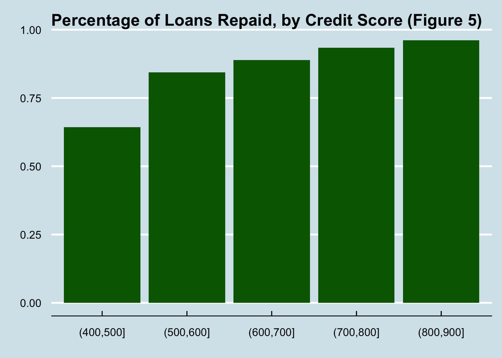

```r
ggplot(mean_data_by_crd_score, aes(x = score_range, y = pctg_repaid)) + geom_bar(stat='identity', fill = "darkgreen") + theme_economist() + ggtitle("Percentage of Loans Repaid, by Credit Score (Figure 5)")+ xlab("") + ylab("")
```

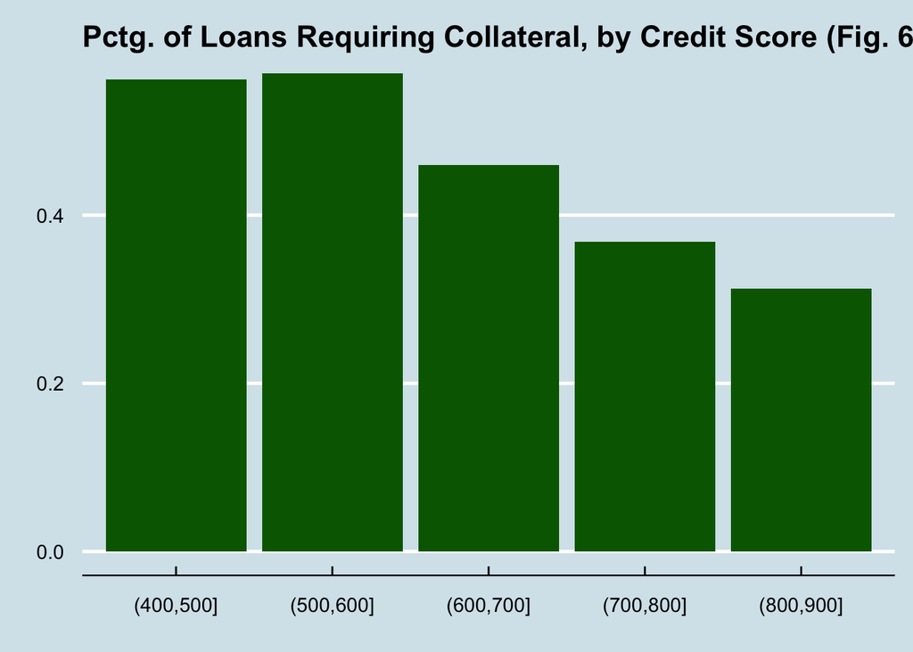

```r
ggplot(mean_data_by_crd_score, aes(x = score_range, y = pctg_collateral_needed)) + geom_bar(stat='identity', fill = "darkgreen") + theme_economist() + ggtitle("Pctg. of Loans Requiring Collateral, by Credit Score (Fig. 6)") + xlab("") + ylab("")
```

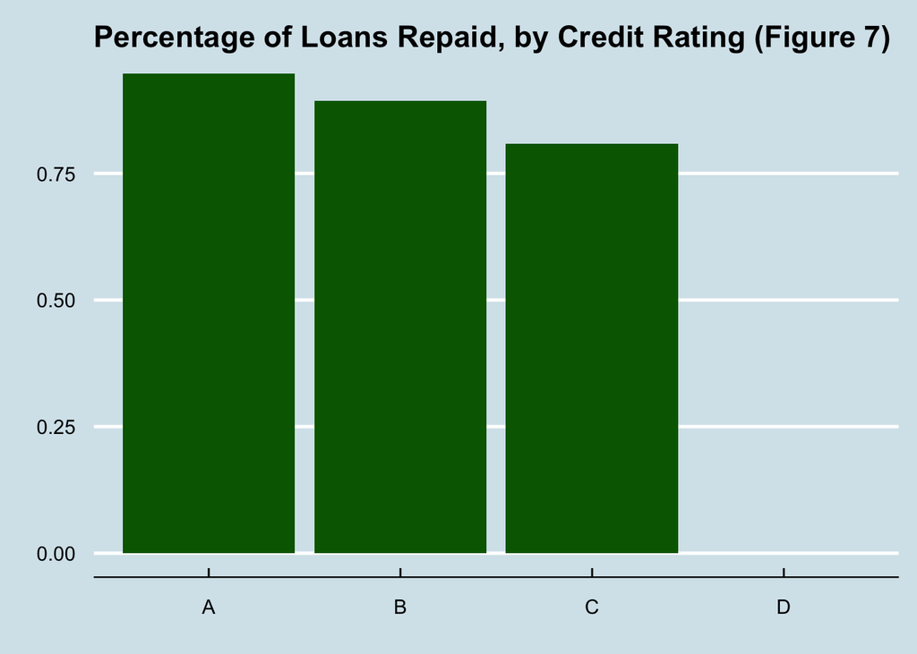

```r
ggplot(mean_data_by_crd_ratings, aes(x = credit_rating, y = pctg_repaid)) + geom_bar(stat='identity', fill = "darkgreen") + theme_economist() + ggtitle("Percentage of Loans Repaid, by Credit Rating (Figure 7)")+ xlab("") + ylab("")
```

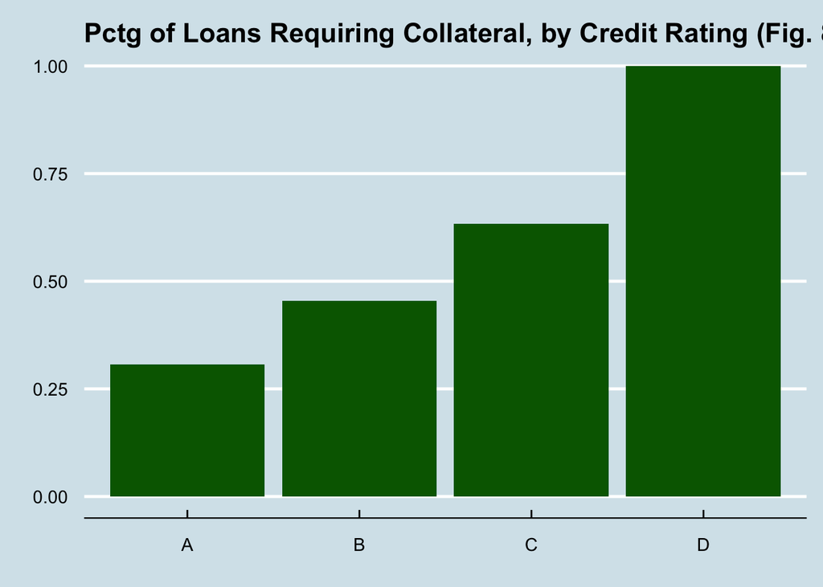

```r
 ggplot(mean_data_by_crd_ratings, aes(x = credit_rating, y = pctg_collateral_needed)) + geom_bar(stat='identity', fill = "darkgreen") + theme_economist() + ggtitle("Pctg of Loans Requiring Collateral, by Credit Rating (Fig. 8)") + xlab("") + ylab("")
```

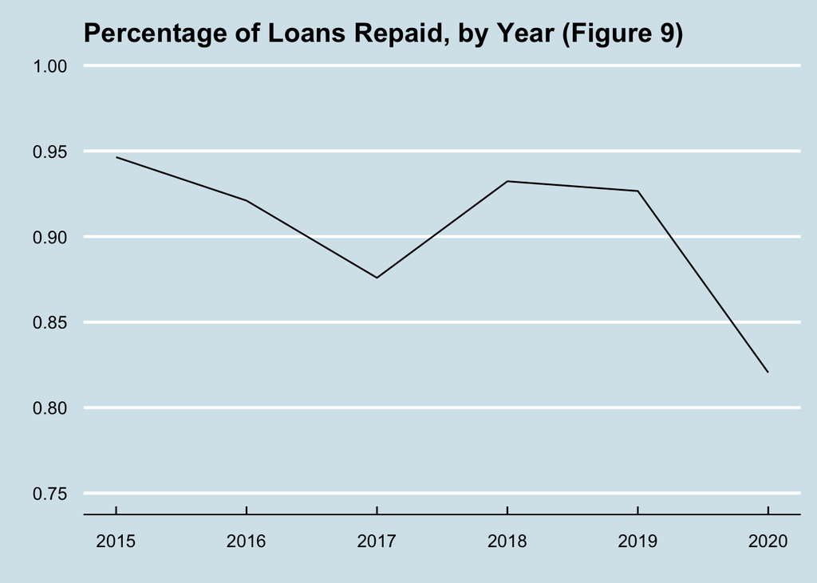

```r
ggplot(mean_data_by_year, aes(x = issue_year, y = pctg_repaid)) + geom_line() + theme_economist() + ggtitle("Percentage of Loans Repaid, by Year (Figure 9)")+ xlab("") + ylab("") + ylim(0.75, 1)
```

## Are there any seasonal or calendar effects in the data set?

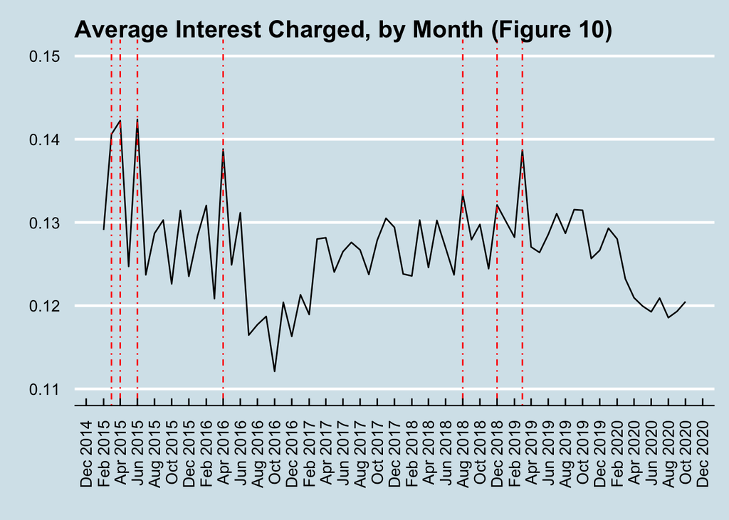

```r
avg_interest_overtime <-   loan_tape_data %>%
                          group_by(issue_month) %>%
                          summarize(avg_interest = mean(interest_rate))
important_dates <- head(avg_interest_overtime[order(-avg_interest_overtime$avg_interest),], 7)[,1]

# Plotting interest rates by month
loan_tape_data %>%
            group_by(issue_month) %>%
            summarize(avg_interest = mean(interest_rate)) %>%
            ggplot(aes(x = issue_month, y = avg_interest)) +
            geom_line() + theme_economist() +
            ggtitle("Average Interest Charged, by Month (Figure 10)") +
            ylim(0.11, 0.15) + xlab("") + ylab("") +
            scale_x_date(date_labels = "%b 20%y",date_breaks = "2 months") +
            theme(axis.text.x = element_text(angle = 90, vjust = 0.5, hjust = 1)) +
            geom_vline(important_dates, mapping = aes(xintercept = issue_month),
             linetype = 4, colour = "red")
```

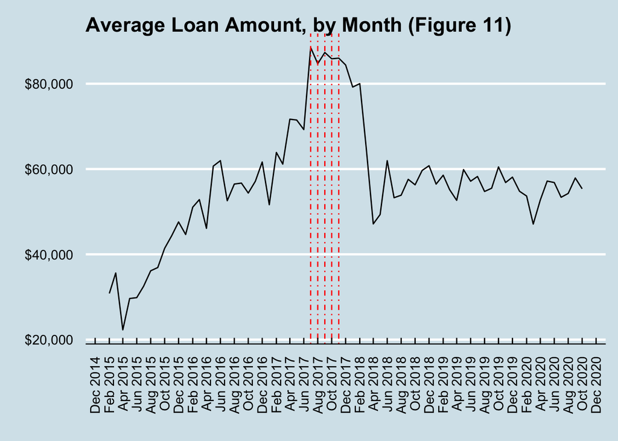

```r
avg_loan_overtime <- loan_tape_data %>%
                      group_by(issue_month) %>%
                      summarize( average_loan_amount = mean(loan_amount) )
important_dates2 <- head(avg_loan_overtime[order(-avg_loan_overtime$average_loan_amount),], 5)[,1]


# Plotting average loan amounts by month
loan_tape_data %>%
            group_by(issue_month) %>%
            summarize( average_loan_amount = mean(loan_amount) ) %>%
            ggplot(aes(x = issue_month, y = average_loan_amount)) +
            geom_line() + theme_economist() +
            ggtitle("Average Loan Amount, by Month (Figure 11)") +
             xlab("") + ylab("") +
            scale_x_date(date_labels = "%b 20%y", date_breaks = "2 months") +
            theme(axis.text.x = element_text(angle = 90, vjust = 0.5, hjust = 1)) +
            scale_y_continuous(labels = scales::dollar_format()) +
            geom_vline(important_dates2, mapping = aes(xintercept = issue_month),
             linetype = 4, colour = "red")
```

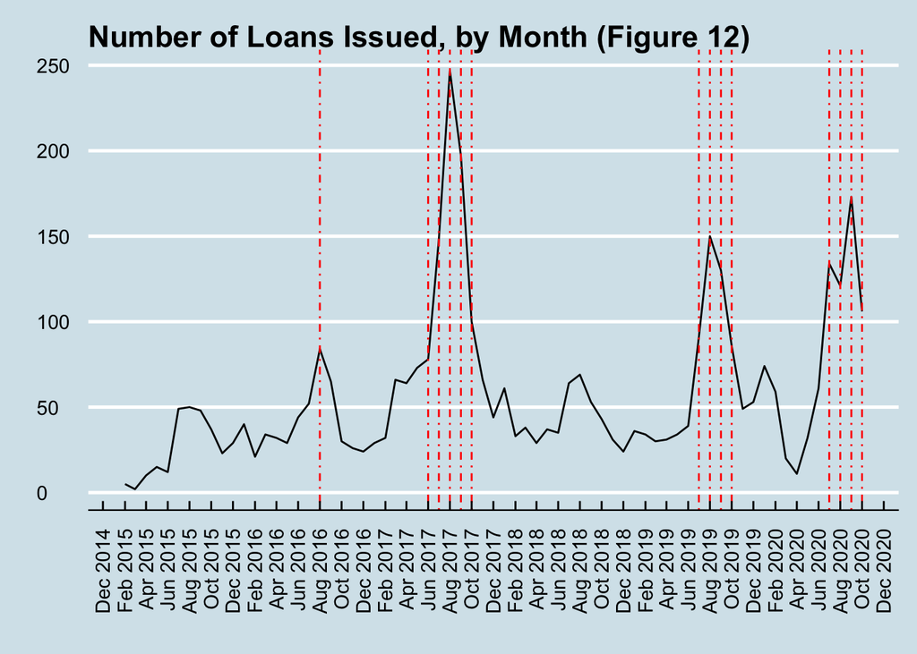

```r
loans_issued_over_time <- (loan_tape_data %>%
                           group_by(issue_month) %>%
                           summarize( loans_issued = length(loan_id) ))
important_dates3 <- head(loans_issued_over_time[order(-loans_issued_over_time$loans_issued),], 14)[,1]


# Plotting number of loans issues by month
# Plotting average loan amounts by month
loan_tape_data %>%
            group_by(issue_month) %>%
            summarize( loans_issued = length(loan_id) ) %>%
            ggplot(aes(x = issue_month, y = loans_issued)) +
            geom_line() + theme_economist() +
            ggtitle("Number of Loans Issued, by Month (Figure 12)") +
             xlab("") + ylab("") +
            scale_x_date(date_labels = "%b 20%y", date_breaks = "2 months") +
            theme(axis.text.x = element_text(angle = 90, vjust = 0.5, hjust = 1)) +
            geom_vline(important_dates3, mapping = aes(xintercept = issue_month),
             linetype = 4, colour = "red")
```

## What factors appear to drive loan performance (repaid vs. defaulted)?

### When regressing `loan_status` on `credit_score`, the coefficient on `credit_score` is statistically significant.

### In other words, it seems to be the case that an individual’s `credit_score` can be a good indicator as to whether or not they will repay the loan. The same applies to `credit_rating`, as seen in the output below.

```r
stargazer( lm( loan_status ~ credit_score, data = loan_tape_data ), type = "html" )
```

|  | *Dependent variable:* |
| --- | --- |
|  | loan_status |
| credit_score | 0.001*** |
|  | (0.0001) |
| Constant | 0.493*** |
|  | (0.039) |
| Observations | 3,976 |
| R<sup>2</sup> | 0.027 |
| Adjusted R<sup>2</sup> | 0.026 |
| Residual Std. Error | 0.306 (df = 3974) |
| F Statistic | 108.303*** (df = 1; 3974) |
| *Note:* | p<0.1; p<0.05; p<0.01 |

```r
stargazer( lm( loan_status ~ credit_rating, data = loan_tape_data ), type = "html" )
```

|  | *Dependent variable:* |
| --- | --- |
|  | loan_status |
| credit_ratingB | -0.054*** |
|  | (0.011) |
| credit_ratingC | -0.139*** |
|  | (0.014) |
| credit_ratingD | -0.947*** |
|  | (0.306) |
| Constant | 0.947*** |
|  | (0.009) |
| Observations | 3,976 |
| R<sup>2</sup> | 0.026 |
| Adjusted R<sup>2</sup> | 0.025 |
| Residual Std. Error | 0.306 (df = 3972) |
| F Statistic | 35.404*** (df = 3; 3972) |
| *Note:* | p<0.1; p<0.05; p<0.01 |

## Any concerns about the quality of the data? Any individual loans that warrant additional discussion with the originator?

### Yes, I have found two outliers in this dataset.

### (1) One of the loans had a corresponding amount of $500K; this value is significantly larger than all other loans. Moreover, although the corresponding credit score is relatively high (at 714), no collateral was asked. This makes me concerned about that quality of that specific observation in the dataset.

### (2) Additionally, one of the loans (with id “102096”) had an issue date of 2028. This was clearly a typo.

# Final Thoughts

### (i) Credit Scores:

**Based on `Table 1`, the company tends to provide `larger loans` to people that have `lower credit scores`.** **Nonetheless, the `interest` that is charged on those loans is also `higher for individuals with low scores`.**

**When it comes to the `loan_to_ratio` variable, it is directly related to `credit scores`. That is to say that `loan_to_ratio` tends to be `higher for individuals with high credit scores`.**

**The `percentage of loans repaid` is directly correlated with `credit scores` (`Fig. 5`). In other words, individuals with high credit scores are more likely to repay their loans..**

**Lastly, loans granted to individuals with `high credit scores` are `less likely to need collaterals` as part of the process (`Fig 6`).**

### (ii) Credit Ratings:

**From `Table 2`, `only one` of the loans was granted to a business with a `'D'-Credit Rating`; that loan was `not repaid`.**

**Additionally, `most loans` were granted to businesses with a `B-Rating`. Companies with Ratings of `A, B, C, D` received respectively `1178, 2010, 787, and 1` loans.**

**`Table 2` also highlights the fact that: `interest` is `higher for low-rated companies`, `loan_to_value` is `higher for high-rated companies`, `high-rated companies` are `less likely to default` (`Fig. 7`), and `low-rated companies` are `more likely to need a collateral` (`Fig. 8`).**

### (iii) Time Series:

**Overall, `Interest Rates` have remained `constant over time`, in between 12 and 14 percent (as seen in `Fig. 2`) .**

**`Loan_to_values` have also remained `constant over time`, in between 80 and 85 percent (as seen in `Fig. 3`).**

**Whether a `collateral` was required has also remained `constant over time` (slightly higher in 2016); It has been between 40 and 50 percent (as seen in `Fig. 4`).**

**Loans issued in 2017-2018 were the most generous, as seen in `Table 3` and `Fig 1`**

**Lastly, `loans issues in 2020` were significantly `less likely to be repaid`. This can be seen in `Table 3` and `Fig. 9`.**

### (iv) Seasonal Effects:**

**When it comes to `interest charged`, there were `no seasonal effects` (as seen in `Fig. 10`).**

**When it comes to `loan amounts`, there are also `no consistent patterns` in the data - although it had a `peak in Aug-Dec 2017` (`Fig. 11`).**